# A Risk-based Assessment for R Package Accuracy

## Abstract

This contribution has the aim to discuss possible risk-based approaches to assess R package accuracy within a validated infrastructure. Ideas and suggestions reflect current thinking of the R Validation Hub working group, which is a cross-industry initiative funded by the R Consortium. Our mission is to enable the use of R by the bio-pharmaceutical industry in a regulatory setting, where the output may be used in submissions to regulatory agencies. In this setting, R is required to be part of a validated system, which encompasses software accuracy, reproducibility and traceability. We differentiate two types of R packages: Core and recommended packages are shipped with the basic installation. A rigorous software development lifecycle assures minimal risk. However, contributed packages may vary in their accuracy and development rigor, which could be assessed by various metrics. This cross-industry WG suggested several relevant quality metrics, and is developing an R package that provides a workflow to evaluate the quality of a set of R packages. This work may also be relevant in other regulated areas such as financial service industries and agriculture.

*Accepted for presentation at useR! 2020*

## R Validation Hub

- R Consortium Working Group
- approx. 100 members; > 50 organizations

> **Mission:** R Validation Hub is a cross-industry initiative whose mission is to enable the use of R by the Bio-Pharmaceutical Industry in a regulatory setting, where the output may be used in submissions to regulatory agencies.

## Resources

Website [www.pharmaR.org](https://www.pharmaR.org/)

- Blog posts
- Presentations
- White paper

Tools available on [GitHub](https://github.com/pharmaR/riskmetric)

- R Package `riskmetric`
- Risk Assessment App

## Regulations

- ICH.: The International Council for Harmonisation of Technical Requirements for Pharmaceuticals for Human Use “…software used should be reliable, and documentation of appropriate software testing procedures should be available”
- FDA. US Food and Drug Administration: Glossary of Computer System Software Development Terminology “Validation […] provides a high degree of *assurance* that a specific process *consistently* produces a product meeting its *predetermined specifications* and quality attributes.”

## Validating `R`

- *Core R*, base and recommended packages, owned by the R Foundation
- *Contributed R packages* from the community: Different owners, varying quality, many are essential to make good use of R

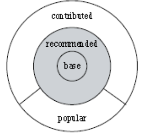

Source: German et al (2013); 10.1109/CSMR.2013.33

## Core R

- The R Foundation follows many good practices during the SDLC of core R.Software Development Life Cycle: A Description of R’s Development, Testing, Release and Maintenance Processes
- Statement on Regulatory Compliance and Validation Issues.Regulatory Compliance and Validation Issues: A Guidance Document for the Use of R in Regulated Clinical Trial Environments (2018)
- **It can be concluded that there is minimal risk in using Core R for regulatory analysis and reporting**

## Contributed Packages

Intent-to-use package or indirect import?

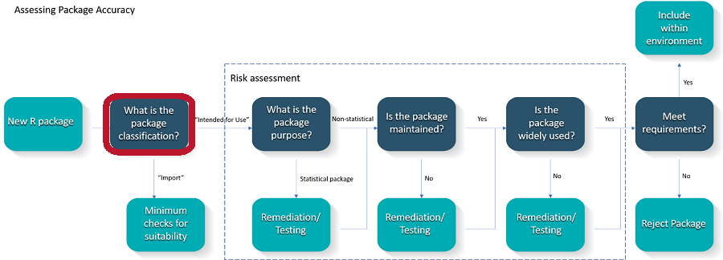

Source: White Paper by Nicholls et al. (2020)

## Contributed Packages

Is a statistical method implemented?

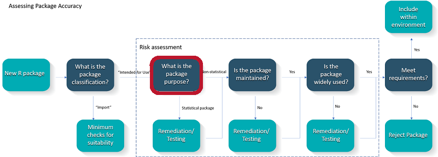

Source: White Paper by Nicholls et al. (2020)

## Contributed Packages

Are good maintance practice fulfilled?

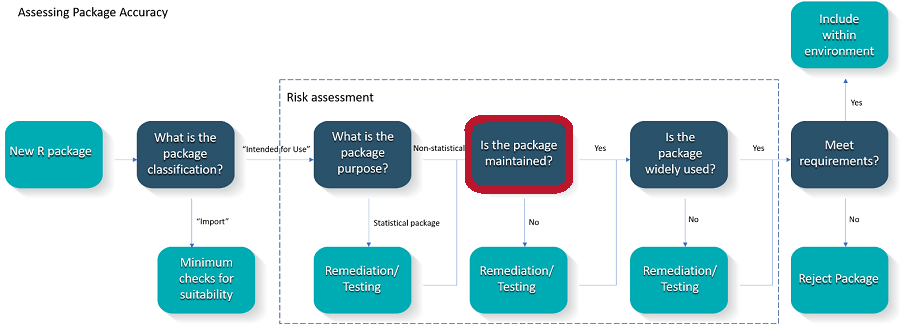

Source: White Paper by Nicholls et al. (2020)

## Contributed Packages

What is the community usage and testing?

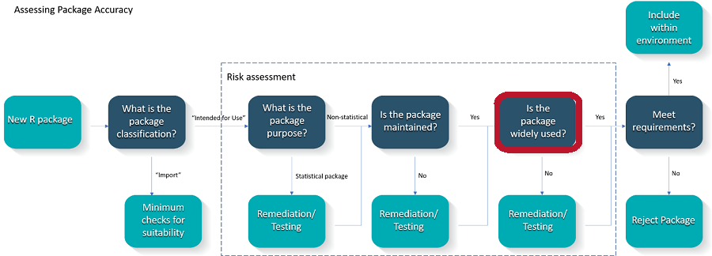

Source: White Paper by Nicholls et al. (2020)

## Contributed Packages

Submission-relevant or explorative analysis?

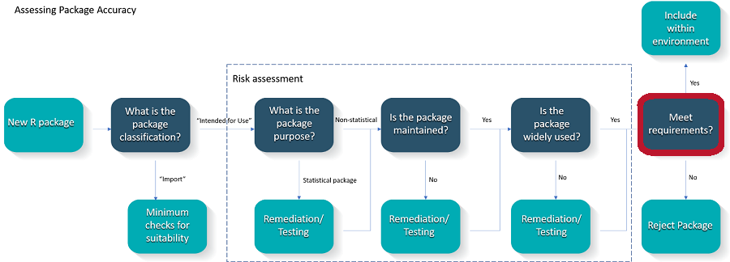

Source: White Paper by Nicholls et al. (2020)

## R Package `riskmetric`

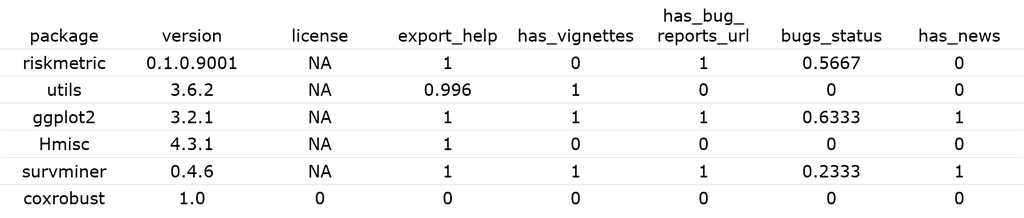

```r
library(riskmetric)
pkg_tbl <- pkg_ref(c("riskmetric", "utils",
                    "ggplot2", "Hmisc",
                    "survminer", "coxrobust"))
res <- pkg_tbl %>%
  pkg_assess() %>%
  pkg_score() %>%
  mutate(risk = summarize_scores(.))
```

## Summary

[figure not shown]

## Thanks for your Interest!